# Quadratic_Discriminant_Analysis

```python
import pandas as pd
import numpy as np

from sklearn.discriminant_analysis import QuadraticDiscriminantAnalysis
from sklearn.metrics import confusion_matrix, plot_confusion_matrix, classification_report, precision_score

import statsmodels.api as sm
import statsmodels.formula.api as smf

# Visualisation libraries

## Text
from colorama import Fore, Back, Style
from IPython.display import Image, display, Markdown, Latex, clear_output

## seaborn
import seaborn as sns
sns.set_style("whitegrid")
sns.set_context("paper", rc={"font.size":12,"axes.titlesize":14,"axes.labelsize":12})

## matplotlib
import matplotlib.pyplot as plt
from matplotlib.font_manager import FontProperties
from matplotlib.patches import Ellipse, Polygon
import matplotlib.gridspec as gridspec
import matplotlib.colors
from pylab import rcParams
from matplotlib.font_manager import FontProperties
from mpl_toolkits.axes_grid1.inset_locator import inset_axes
plt.style.use('seaborn-whitegrid')
import matplotlib as mpl
mpl.rcParams['figure.figsize'] = (17, 6)
mpl.rcParams['axes.labelsize'] = 14
mpl.rcParams['xtick.labelsize'] = 12
mpl.rcParams['ytick.labelsize'] = 12
mpl.rcParams['text.color'] = 'k'
%matplotlib inline

import warnings
warnings.filterwarnings("ignore")
```

[Home](https://hatefdastour.github.io/) / [Statistical Learning](https://hatefdastour.github.io/notes/Statistical_Learning//)

## Chapter 4: Classification

- [**Logistic Regression**](https://hatefdastour.github.io/notes/Statistical_Learning/Logistic_Regression.html)
- [**Linear Discriminant Analysis**](https://hatefdastour.github.io/notes/Statistical_Learning/Linear_Discriminant_Analysis.html)
- [**Quadratic Discriminant Analysis**](https://hatefdastour.github.io/notes/Statistical_Learning/Quadratic_Discriminant_Analysis.html)
- [**K Nearest Neighbors**](https://hatefdastour.github.io/notes/Statistical_Learning/K_Nearest_Neighbors.html)

**The Stock Market Data**

The Smarket data is part of the the [**ISLR package**](https://cran.r-project.org/web/packages/ISLR/index.html). This dataset consists of percentage returns for the S&P 500 stock index over 1, 250 days, from the beginning of 2001 until the end of 2005. This dataset can be extracted from the [**ISLR package**](https://cran.r-project.org/web/packages/ISLR/index.html) using the following syntax.

```
library (ISLR)
write.csv(Smarket, "Smarket.csv")
```

```python
Smarket = pd.read_csv('Data/Smarket.csv', index_col=0)
Smarket.head()
```

|  | Year | Lag1 | Lag2 | Lag3 | Lag4 | Lag5 | Volume | Today | Direction |
| --- | --- | --- | --- | --- | --- | --- | --- | --- | --- |
| 1 | 2001 | 0.381 | -0.192 | -2.624 | -1.055 | 5.010 | 1.1913 | 0.959 | Up |
| 2 | 2001 | 0.959 | 0.381 | -0.192 | -2.624 | -1.055 | 1.2965 | 1.032 | Up |
| 3 | 2001 | 1.032 | 0.959 | 0.381 | -0.192 | -2.624 | 1.4112 | -0.623 | Down |
| 4 | 2001 | -0.623 | 1.032 | 0.959 | 0.381 | -0.192 | 1.2760 | 0.614 | Up |
| 5 | 2001 | 0.614 | -0.623 | 1.032 | 0.959 | 0.381 | 1.2057 | 0.213 | Up |

Let's divide this dataset into train and test sets. In doing so, the data before 2005 is considered for the train set and the data from 2005 onward for the test set. That is

```python
X_train, y_train = Smarket.loc[(Smarket['Year'] < 2005), ['Lag1','Lag2']], Smarket.loc[(Smarket['Year'] < 2005), ['Direction']]
X_test, y_test = Smarket.loc[(Smarket['Year'] >= 2005), ['Lag1','Lag2']], Smarket.loc[(Smarket['Year'] >= 2005), ['Direction']]

pd.DataFrame(data={'Set':['X_train','X_test','y_train','y_test'],
               'Shape':[X_train.shape, X_test.shape, y_train.shape, y_test.shape]}).set_index('Set').T
```

| Set | X_train | X_test | y_train | y_test |
| --- | --- | --- | --- | --- |
| Shape | (998, 2) | (252, 2) | (998, 1) | (252, 1) |

## Quadratic Discriminant Analysis

We know that LDA assumes the observations within each class are drawn from a multivariate Gaussian distribution with a class-specific mean vector and a covariance matrix that is common to all $K$ classes.

Similar to LDA, the QDA classifier results from assuming that the observations from each class are drawn from a Gaussian distribution, and plugging estimates for the parameters into Bayes’ theorem to perform prediction.

However, there is a major difference between LDA and QDA. LDA assumes the feature **covariance matrices** of classes are the same. This results in a linear decision boundary. On the other hand, QDA is less strict and allows different feature covariance matrices for different classes, which leads to a quadratic decision boundary.

In other words, QDA assumes that each class has its own covariance matrix. QDA assumes that an observation from the $k$th class is of the form $X ∼ N(\mu_k,~\Sigma_k)$, where $\Sigma_k$ is a covariance matrix for the $k$th class. Under this assumption, the Bayes classifier assigns an observation $X = x$ to the class for which

$$\delta_k(x) = −\frac{1}{2} \left(x - \mu_k\right)^T \Sigma_k^{-1} \left(x - \mu_k\right) −\frac{1}{2}\log\left| \Sigma_k\right| + \log \pi_k$$

is the largetst. Thus, the QDA classifier involves plugging estimates for $\Sigma_k$, $\mu_k$, and $\pi_k$ into the above equation.

We can do a Quadratic Discriminant Analysis (QDA) using [**sklearn QDA**](https://scikit-learn.org/0.16/modules/generated/sklearn.qda.QDA.html):

```python
QDA = QuadraticDiscriminantAnalysis()
# Predictions
y_pred = QDA.fit(X_train, y_train).predict(X_test)
```

- **Prior probabilities of groups:**

```python
Class_Names = list(np.sort(Smarket.Direction.unique()))
PriorProbabilities = pd.DataFrame(QDA.priors_, columns = {'Prior probabilities of groups'}, index = Class_Names)
display(PriorProbabilities.T.round(3))
print('%.2f percent of the training observations correspond to days during which the market went down.' %
        (100*PriorProbabilities.loc['Down'].values[0]))
```

|  | Down | Up |
| --- | --- | --- |
| Prior probabilities of groups | 0.492 | 0.508 |

```
49.20 percent of the training observations correspond to days during which the market went down.
```

- **Group means:**

These are the average of each predictor within each class, and are used by LDA as estimates of $\mu_k$.

```python
GroupMeans = pd.DataFrame(QDA.means_, columns =X_train.columns, index = Class_Names)
display(GroupMeans.round(4))
```

|  | Lag1 | Lag2 |
| --- | --- | --- |
| Down | 0.0428 | 0.0339 |
| Up | -0.0395 | -0.0313 |

- **Classification Report:**

```python
Results = pd.DataFrame(classification_report(y_test, y_pred,
                                             target_names=Class_Names, output_dict=True)).T
display(Results.round(4))
```

|  | precision | recall | f1-score | support |
| --- | --- | --- | --- | --- |
| Down | 0.6000 | 0.2703 | 0.3727 | 111.0000 |
| Up | 0.5990 | 0.8582 | 0.7055 | 141.0000 |
| accuracy | 0.5992 | 0.5992 | 0.5992 | 0.5992 |
| macro avg | 0.5995 | 0.5642 | 0.5391 | 252.0000 |
| weighted avg | 0.5994 | 0.5992 | 0.5589 | 252.0000 |

- **Confusion Matrix**:

A confusion matrix is a table that is often used to describe the performance of a classification model (classifier) on a set of test data, **X_test** and **y_test**.

```
Confusion Matrix
```

|  | Down | Up |
| --- | --- | --- |
| Down | 30 | 81 |
| Up | 20 | 121 |

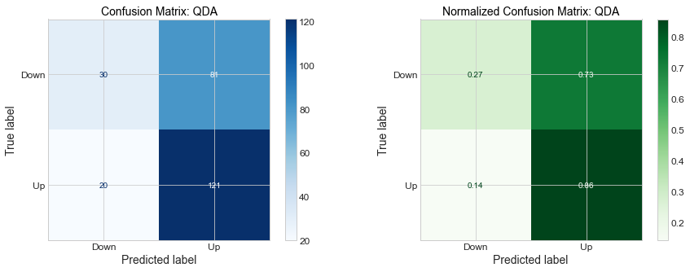

```python
print(Back.CYAN + Fore.BLACK + Style.BRIGHT + 'Confusion Matrix'  + Style.RESET_ALL)
display(pd.DataFrame(data = confusion_matrix(y_test, y_pred), index = Class_Names, columns = Class_Names))

fig, ax = plt.subplots(1, 2, figsize=(15, 5))

_ = plot_confusion_matrix(QDA, X_test, y_test, display_labels= Class_Names, cmap= "Blues", normalize= None, ax = ax[0])
_ = ax[0].set_title('Confusion Matrix: QDA')

_ = plot_confusion_matrix(QDA, X_test, y_test, display_labels= Class_Names, cmap= "Greens", normalize= 'true', ax = ax[1])
_ = ax[1].set_title('Normalized Confusion Matrix: QDA')
```

## Refrences

1. James, G., Witten, D., Hastie, T., & Tibshirani, R. (2013). [An introduction to statistical learning](https://link.springer.com/book/10.1007/978-1-4614-7138-7) (Vol. 112, pp. 3-7). New York: springer.
2. Jordi Warmenhoven, ISLR-python
3. James, G., Witten, D., Hastie, T., & Tibshirani, R. (2017). [ISLR: Data for an Introduction to Statistical Learning with Applications in R](https://cran.r-project.org/web/packages/ISLR/index.html)